# QEcoGen Lab

# Home

## Laboratory of Quantitative Ecological Genetics (QEcoGen)

Welcome, we are studying plant ecological genetics with quantitative tools. Our lab is located in the Sapporo campus of Hokkaido University, Japan. Admission schedule for prospective graduate students is available on the official website of [Graduate School of Environmental Science](https://www.ees.hokudai.ac.jp/?lang=en). For scholarship information, please see the website of [Ministry of Education, Culture, Sports, Science and Technology (MEXT)](https://www.mext.go.jp/en/policy/education/highered/title02/detail02/sdetail02/1373897.htm). Currently we have no open call for postdoc positions, but you may consider [JSPS International Fellowships](https://www.jsps.go.jp/english/e-fellow/). If you wish to join our group, please send your CV and research interest to Yasuhiro Sato (yassato”at”ees.hokudai.ac.jp).

### News

See [Bluesky@yassato.bsky.social](https://bsky.app/profile/yassato.bsky.social)

# Research

### **Quantitative Ecological Genetics of Biotic Interaction**

We are interested in how genetic variation shapes, and is shaped by, biotic interactions. To analyze quantitative genetic variation in complex ecological traits, our research employs cutting-edge tools of computational biology and functional genomics. Currently, we are working on plants and insects, but other projects involving biotic interactions are also welcome.  
**Keywords: Plant Ecology, Quantitative Genetics, Biotic Interaction**

#### **1. Quantitative Genetics of Plant-Plant Interaction**

Plants cannot escape from neighboring individuals in the field, making plant-plant interactions unavoidable in a local space. Despite the prevalence of neighboring plant-plant interactions, these interactions are not always attributable to a single trait or gene. To dissect the genetic architecture of intraspecific plant-plant interactions, we developed new methods named “Neighbor GWAS” (Sato et al. 2021 Heredity) and “Neighbor QTL” (Sato et al. 2021 G3). These methods are being applied to the analysis of insect herbivory and communities on *Arabidopsis thaliana* accessions (Sato et al. 2024 Nature Communications) in addition to other quantitative traits in crops, trees, etc… We are also seeking the potential application of intraspecific plant-plant interactions to improve plant resistance and yield by mixed planting.

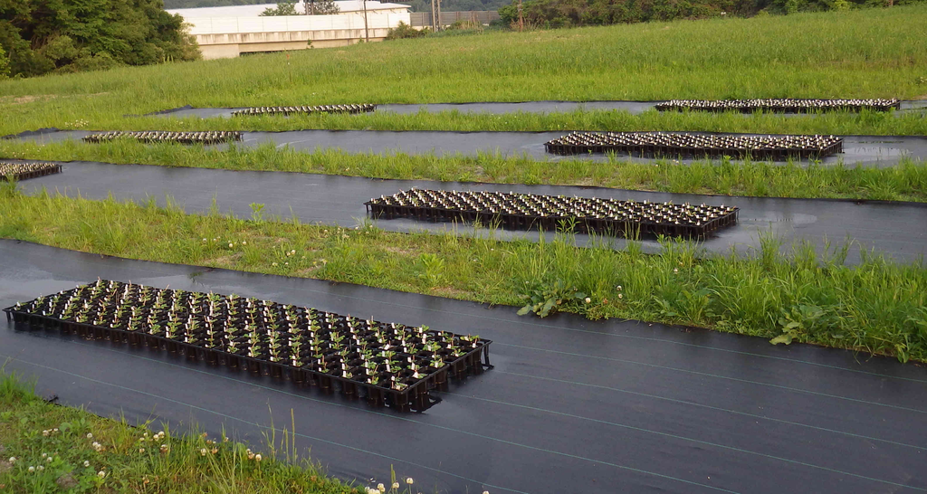

Field experiment using *Arabidopsis thaliana* accessions. Modified from Sato et al. (2021) Heredity

#### **2. Evolutionary Ecology of Plant Defense Against Herbivores**

Plants develop various defense traits against herbivores. Such anti-herbivore defense traits exhibit polymorphisms within a natural plant population, which leads us to ask how these polymorphisms can be maintained in nature. By focusing on neighboring plants, we found that hairy plants were less damaged by a leaf beetle when surrounded by glabrous plants in the wild herb *Arabidopsis halleri*. Such neighbor effects further exerted negative frequency-dependent selection on *GLABRA1*-based trichome dimorphism (Sato & Kudoh 2017 American Naturalist; Sato et al. 2017 Functional Ecology). These findings highlight the importance of neighbor effects in the maintenance of genetic variation in anti-herbivore defense traits (reviewed in Sato 2018 Plant Species Biology).

[figure not shown]

Hairy *Arabidopsis halleri* (left) and larval *Phaedon brassicae* (right) from [Plant Species Biology Vol. 33(2)](https://esj-journals.onlinelibrary.wiley.com/toc/14421984/2018/33/2)

#### **3. Data Analysis in Ecology, Evolution, and Genetics**

Our research often employs statistical tools to untangle complex ecological interactions. This experience enables us to not only develop new methods (Sato et al. 2023 Evolution) but also collaborate with other research areas (e.g., Takimoto & Sato et al. 2021 Ecological Informatics). Data from plant ecology and genomics are especially welcome for potential collaboration.

# Publication

*†Equal contribution; *Correspondence*  
*See also [Google scholar citations](https://scholar.google.co.jp/citations?hl=en&user=HbrGYr8AAAAJ&view_op=list_works&sortby=pubdate).*

## Preprint

1. **Sato Y***. (2025) Negative frequency-dependent selection underlies overyielding through neighbor genotypic effects in *Arabidopsis thaliana*. *bioRxiv* https://doi.org/10.1101/2025.05.14.654149
2. Akram I, Rohr L, Shimizu KK, Shimizu-Inatsugi R, **Sato Y***. (2025) Spatial heterogeneity of disease infection attributable to neighbor genotypic identity in barley cultivars. *bioRxiv* https://doi.org/10.1101/2025.04.22.650038

## Peer-reviewed articles

1. **Sato Y***, Shimizu-Inatsugi R, Takeda K, Schmid B, Nagano AJ*, Shimizu KK*. (2024) Reducing herbivory in mixed planting by genomic prediction of neighbor effects in the field. *Nature Communications* 15:8467. https://doi.org/10.1038/s41467-024-52374-7 [Media release at University of Zurich; [EN](https://www.news.uzh.ch/en/articles/media/2024/Using-Biodiversity.html), [DE](https://www.news.uzh.ch/de/articles/media/2024/Schaedlinge.html)]
2. Stockenhuber R, Akiyama R, Tissot N, Milosavljevic S, Yamazaki M, Wyler M, Arongaus AB, Podolec R, **Sato Y**, Widmer A, Ulm R*, Shimizu KK*. (2024) UV RESISTANCE LOCUS 8-mediated UV-B response is required alongside CRYPTOCHROME 1 for plant survival in sunlight under field conditions. *Plant and Cell Physiology* 65:35-48. https://doi.org/10.1093/pcp/pcad113
3. The Herbivory Variability Network. (2023) Plant size, latitude, and phylogeny explain variability in herbivory. *Science* 382:679-683. https://doi.org/10.1126/science.adh8830 [a consortium paper incl. Y. Sato as one of the co-authors]
4. Xu C†, **Sato Y**†*, Yamazaki M, Brasser M, Barbour MA, Bascompte J, Shimizu KK*. (2023) Genome-wide association study of aphid abundance highlights a locus affecting plant growth and flowering in *Arabidopsis thaliana*. *Royal Society Open Science* 10:230399. https://doi.org/10.1098/rsos.230399
5. **Sato Y***, Takahashi Y, Xu C, Shimizu KK*. (2023) Detecting frequency-dependent selection through the effects of genotype similarity on fitness components. *Evolution* 77:1145–1157. https://doi.org/10.1093/evolut/qpad028 [[Vignette](https://yassato.github.io/RegressionFDS/)]
6. Shimizu-Inatsugi R*, Morishima A, Mourato B, Shimizu KK, **Sato Y**. (2023) Phenotypic variation of a new synthetic allotetraploid *Arabidopsis kamchatica* enhanced in natural environment. *Frontiers in Plant Science* 13:1058522 https://doi.org/10.3389/fpls.2022.1058522
7. Takimoto H†*, **Sato Y**†, Nagano AJ, Shimizu KK, Kanagawa A. (2021) Using a two-stage convolutional neural network to rapidly identify tiny herbivorous beetles in the field. *Ecological Informatics* 66:101466 https://doi.org/10.1016/j.ecoinf.2021.101466
8. **Sato Y**, Yamamoto E, Shimizu KK*, Nagano AJ*. (2021) Neighbor GWAS: incorporating neighbor genotypic identity into genome-wide association studies of field herbivory. *Heredity* 126(4):597–614. https://doi.org/10.1038/s41437-020-00401-w [[R package](https://cran.r-project.org/package=rNeighborGWAS)]
9. **Sato Y**†*, Takeda K†, Nagano AJ*. (2021) Neighbor QTL: an interval mapping method for quantitative trait loci underlying plant neighborhood effects. *G3; Genes|Genomes|Genetics* 11(2):jkab017. https://doi.org/10.1093/g3journal/jkab017 [[R package](https://cran.r-project.org/package=rNeighborQTL)]
10. Shimizu-Inatsugi R*, Milosavljevic S, Shimizu KK, Schaepman-Strub G, Tanoi K, **Sato Y.** (2021) Metal accumulation and its effect on leaf herbivory in an allopolyploid species *Arabidopsis kamchatica* inherited from a diploid hyperaccumulator *A. halleri*. *Plant Species Biology* 36(2):208–217. https://doi.org/10.1111/1442-1984.12304
11. **Sato Y**, Tezuka A, Kashima M, Deguchi A, Shimizu-Inatsugi R, Yamazaki M, Shimizu KK*, Nagano AJ*. (2019) Transcriptional variation in glucosinolate biosynthetic genes and inducible responses to aphid herbivory on field-grown *Arabidopsis thaliana*. *Frontiers in Genetics* 10:787. https://doi.org/10.3389/fgene.2019.00787
12. **Sato Y**, Shimizu-Inatsugi R, Yamazaki M, Shimizu KK*, Nagano AJ*. (2019) Plant trichomes and a single gene *GLABRA1* contribute to insect community composition on field-grown *Arabidopsis thaliana*. *BMC Plant Biology* 19:163. https://doi.org/10.1186/s12870-019-1705-2
13. Nakadai R†*, Hashimoto K†, Iwasaki T, **Sato Y.** (2018) Geographical co-occurrence of butterfly species: the importance of niche filtering by host plant species. *Oecologia* 186(4):995–1005. https://doi.org/10.1007/s00442-018-4062-1
14. **Sato Y**†*, Ito K†, Kudoh H. (2017) Optimal foraging by herbivores maintains polymorphism in defence in a natural plant population. *Functional Ecology* 31(12):2233-2243. https://doi.org/10.1111/1365-2435.12937 [[postprint]](https://repository.kulib.kyoto-u.ac.jp/dspace/handle/2433/228143?locale=en)
15. **Sato Y***, Kudoh H. (2017) Herbivore-mediated interaction promotes the maintenance of trichome dimorphism through negative frequency-dependent selection. *The American Naturalist* 190(3):E67-E77. https://doi.org/10.1086/692603 [[PDF]](https://repository.kulib.kyoto-u.ac.jp/dspace/handle/2433/226924?locale=en)
16. **Sato Y***, Kudoh H. (2017) Fine-scale frequency differentiation along a herbivory gradient in the trichome dimorphism of a wild *Arabidopsis*. *Ecology and Evolution* 7(7):2133-2141. https://doi.org/10.1002/ece3.2830
17. **Sato Y***, Kudoh H. (2016) Presence of substitute diets alters plant resistance to specialist and generalist herbivores: a meta-analysis. *Ecosphere* 7(11):e01446 https://doi.org/10.1002/ecs2.1446
18. **Sato Y***, Kudoh H. (2016) Associational effects against a leaf beetle mediate a minority advantage in defense and growth between hairy and glabrous plants. *Evolutionary Ecology* 30(1):137-154. https://doi.org/10.1007/s10682-015-9809-0 [[postprint]](http://repository.kulib.kyoto-u.ac.jp/dspace/handle/2433/201635?locale=en)
19. **Sato Y***, Sato S. (2015) Spring temperature predicts the long-term molting phenology of two cicadas, *Cryptotympana facialis* and *Graptopsaltria nigrofuscata* (Hemiptera: Cicadidae). *Annals of the Entomological Society of America* 108(4):494-500. https://doi.org/10.1093/aesa/sav036 [[postprint]](http://repository.kulib.kyoto-u.ac.jp/dspace/handle/2433/201636?locale=en)
20. **Sato Y***, Kudoh H. (2015) Tests of associational defence provided by hairy plants for glabrous plants of *Arabidopsis halleri* subsp. *gemmifera* against insect herbivores. *Ecological Entomology* 40(3):269-279. https://doi.org/10.1111/een.12179 [[postprint]](http://repository.kulib.kyoto-u.ac.jp/dspace/handle/2433/201637?locale=en)
21. **Sato Y**, Kudoh H*. (2014) Fine-scale genetic differentiation of a temperate herb: relevance of local environments and demographic change. *AoB PLANTS* 6:plu070. https://doi.org/10.1093/aobpla/plu070
22. **Sato Y***, Kawagoe T, Sawada Y, Hirai MY, Kudoh H. (2014) Frequency-dependent herbivory by a leaf beetle, *Phaedon brassicae*, on hairy and glabrous plants of *Arabidopsis halleri* subsp. *gemmifera*. *Evolutionary Ecology* 28(3):545-559. https://doi.org/10.1007/s10682-013-9686-3 [[postprint]](http://repository.kulib.kyoto-u.ac.jp/dspace/handle/2433/179616?locale=en)
23. **Sato Y***, Kudoh H. (2013) Relative strength of phenotypic selection on the height and number of flowering-stalks in the rosette annual *Cardamine hirsuta* (Brassicaceae). *Journal of Ecology and Environment* 36(3):151-158. https://doi.org/10.5141/ecoenv.2013.151
24. **Sato Y***, Takakura KI, Nishida S, Nishida T. (2013) Dominant occurrence of cleistogamous flowers of *Lamium amplexicaule* in relation to the nearby presence of an alien congener *L. purpureum*. *ISRN Ecology* Article ID:476862. http://dx.doi.org/10.1155/2013/476862

## Peer-reviewed monographs/reviews

1. **Sato Y***, Wuest SE*. (2024) The genetics of plant–plant interactions and their cascading effects on agroecosystems – from model plants to applications. *Plant and Cell Physiology* https://doi.org/10.1093/pcp/pcae092
2. **Sato Y*.** (2018) Associational effects and the maintenance of polymorphism in plant defense against herbivores: review and evidence. *Plant Species Biology* 33(2):91-108. https://doi.org/10.1111/1442-1984.12201 [[postprint]](https://repository.kulib.kyoto-u.ac.jp/dspace/handle/2433/234646?locale=en)
3. Sakata Y*, **Sato Y.** (2017) Evolutionary ecology of plant defense: integrating different spatial scales within and among species (in Japanese). *Japanese Journal of Ecology* 67(3):287-306. https://doi.org/10.18960/seitai.67.3_287

## Peer-reviewed conference proceedings

1. Kuzuhara H, Takimoto H, **Sato Y**, Kanagawa A. (2020) Insect pest detection and identification method based on deep learning for realizing a pest control system. *Proceedings of the Society of Instrument and Control Engineers (SICE) Annual Conference 2020*. pp. 709–714. https://doi.org/10.23919/SICE48898.2020.9240458

## Books/Book chapters

1. **Sato Y**. (2024) Chapter 7: The maintenance of trichome dimorphism through associational effects: a case study of *Arabidopsis halleri* and a leaf beetle (in Japanese). In: Ecology of Plant Defense Against Herbivores (Y. Sakata and T. Tsunoda eds), *Species Biology Series*, Bun-ichi Sogo Shuppan, Tokyo, Japan. ISBN: 978-4-8299-6211-4.
2. **Sato Y**, Muranaka T. (eds). (2023) Trans-Scale Biology of Plants: Integrating genomics, phenomics, and ecology to unveil biodiversity (in Japanese). *Species Biology Series*, Bun-ichi Sogo Shuppan, Tokyo, Japan. ISBN: 978-4-8299-6210-7.

# Team

## Principal Investigator

### Yasuhiro Sato (Assistant Professor)

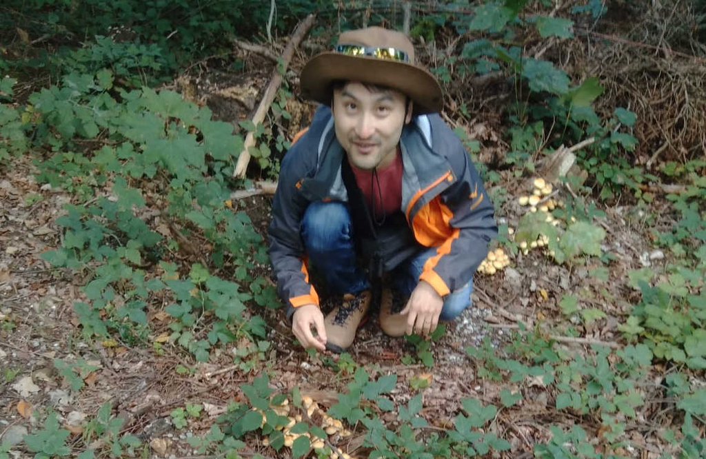

My research career began at Kyoto University in Japan. After obtaining my PhD in 2016, I experienced two postdoc positions in Japan and a senior postdoc position in Switzerland. Since 2024, I have been appointed as a tenure-track assistant professor at Hokkaido University. My research interests include ecological genetics of biotic interactions involving plants. See also CV for the full profile.  
ORCID: 0000-0002-6466-723X; ResearcherID: N-7939-2013

## Postdocs

- **Dr. Tomoki Ishiguro**  
  Tomoki is cross-appointed with [Prof. Utsumi Lab](https://evo-comm-ecology.com/) and assisting our project of plant-plant interactions.

## PhD students

- **Iqra Akram (EXEX Doctoral fellow)**  
  After obtaining MSc in agriculture, Iqra has been working on the genetics of plant-plant interactions in crop species since 2024.

## Master students

*Currently none*

## Support staff

- **Miho Kawagoe (Administrative assistant)**

# Contact

Faculty of Environmental Earth Science, Hokkaido University  
N10W5 Kita-ku, Sapporo 060-0810, Hokkaido, Japan  
Office: B-802 (Group of Ecological Genetics)  
Phone: +81 (0)11 706 4860  
E-mail: yassato”at”ees.hokudai.ac.jp; yassato36c”at”outlook.com

[figure not shown]

From GoogleMap: We are located in the building of Graduate School of Environmental Science.

# JP

Japanese version is available here（日本語版はこちらです）-> [Japanese]